# Homework 3

九月 11, 2020

# Instructions

**Exercises:** 1,3 (Pgs. 90-91); 1 (Pg. 93); 2,4 (Pg. 99); 1,2 (Pg. 101); 2,3,5 (Pg. 104)

**Submission:** Submit via an electronic document on Sakai. Must be submitted as a HTML file generated in RStudio. All assigned problems are chosen according to the textbook *R for Data Science*. You do not need R code to answer every question. If you answer without using R code, delete the code chunk. If the question requires R code, make sure you display R code. If the question requires a figure, make sure you display a figure. A lot of the questions can be answered in written response, but require R code and/or figures for understanding and explaining.

# Chapter 5 (Pgs. 90-91)

## Exercise 1

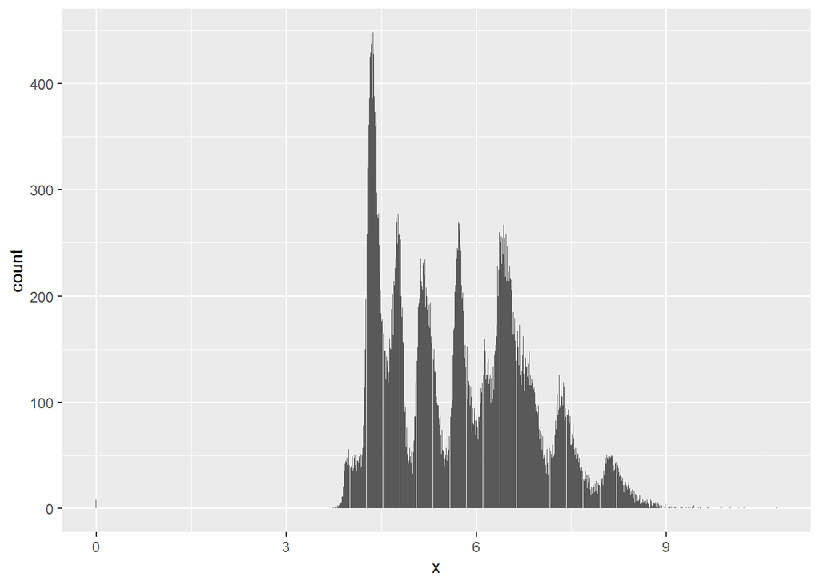

```r
diamonds%>%ggplot(aes(x=x))+geom_bar()
```

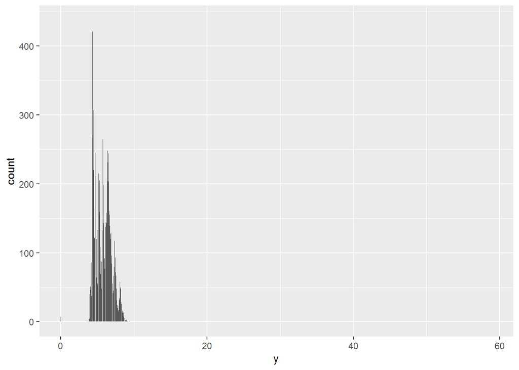

```r
diamonds%>%ggplot(aes(x=y))+geom_bar()
```

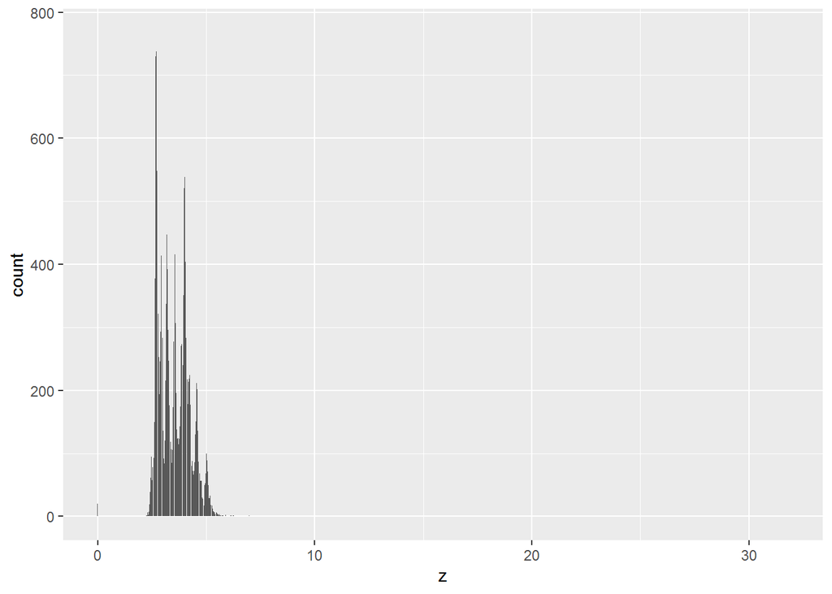

```r
diamonds%>%ggplot(aes(x=z))+geom_bar()
```

```r
count(diamonds, carat==0.99,carat==1)
```

```
## # A tibble: 3 x 3
##   `carat == 0.99` `carat == 1`     n
##   <lgl>           <lgl>        <int>
## 1 FALSE           FALSE        52359
## 2 FALSE           TRUE          1558
## 3 TRUE            FALSE           23
```

The cause of the difference is the difference between 0.99 and 1 is negligible and rounded carat number could make the diamond have better sale. # Chapter 5 (Pg. 93)

## Exercise 1

For the geom_histogram function, it will create a bar with the counts of NA values in this dataset But for the geom_bar function, will refuse to take NA into consideration and automtically disregard them.

# Chapter 5 (Pg. 99)

## Exercise 2

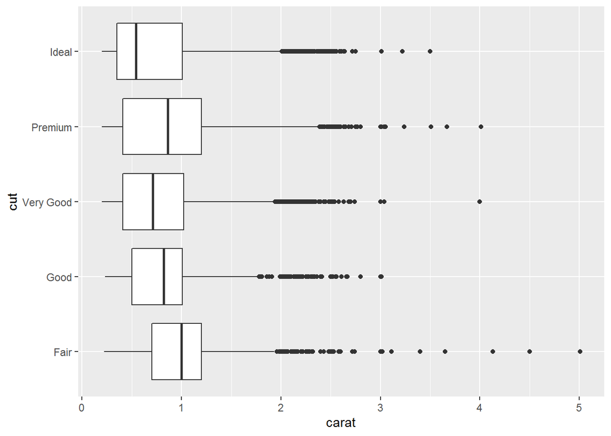

```r
diamonds%>%ggplot(aes(carat,cut))+geom_boxplot()
```

Carat is the best predictor of the price of each diamond, the correlation between carat and cut is when cut is worse, carat tends to have higher median values. So with diamonds with low quality, the higher carat amount will bid up the price. ## Exercise 4

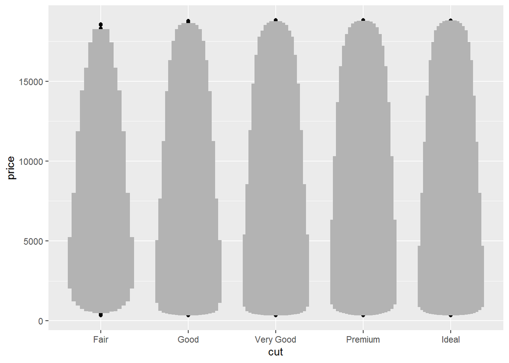

```r
diamonds%>%ggplot(aes(cut,price))+geom_lv()
```

The middle biggest box is for the one half of the data, then as the box goes smaller,it represents the remaining one half of the data. For the graph, it covers approximately 255/256 data points. So the outliers take upfor the remaining 1/256 data points. # Chapter 5 (Pg. 101)

## Exercise 1

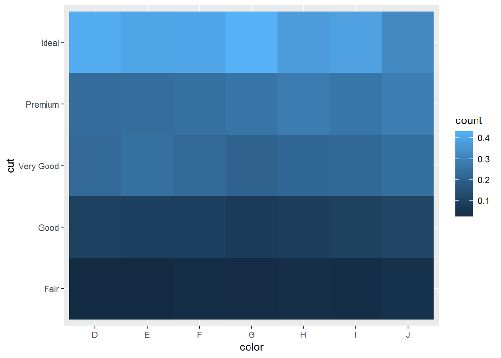

```r
diamonds%>%count(color,cut)%>%group_by(color)%>%mutate(count=n/sum(n))%>%ggplot(aes(color,cut))+geom_tile(aes(fill=count))
```

## Exercise 2

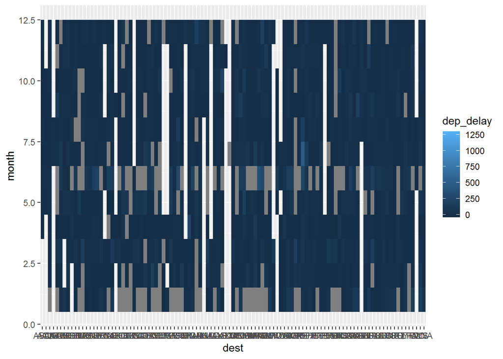

```r
flights%>%group_by(dest,month)%>%mutate(average_dep_delay=mean(dep_delay))%>%ggplot(aes(dest,month))+geom_tile(aes(fill=dep_delay))
```

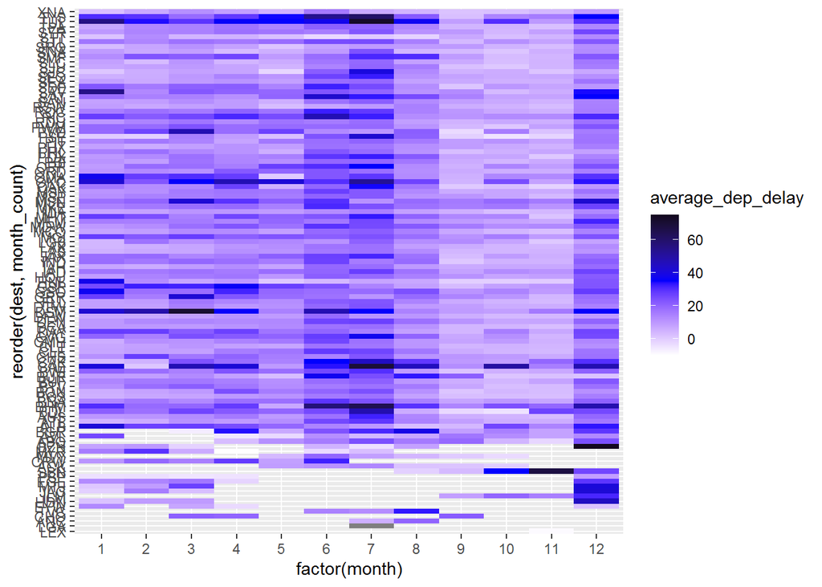

```r
flights%>%group_by(dest,month)%>%summarize(average_dep_delay=mean(dep_delay,na.rm=T))%>%ungroup()%>%group_by(dest)%>%mutate(month_count=n())%>%
  ggplot(aes(factor(month),reorder(dest,month_count)))+geom_tile(aes(fill=average_dep_delay))+ scale_fill_gradient2(low="white",mid="blue",high="black",midpoint=35)
```

It seems very messy since the x values(dest) are way too many to fit into the x-axis.And the color is hard to distinguish. The white parts are the missing values which made the graph difficult to read.

The improved graph is given. I make the dest with missing values to the bottom and change the color to make it more easily to read.

# Chapter 5 (Pg. 104)

## Exercise 2

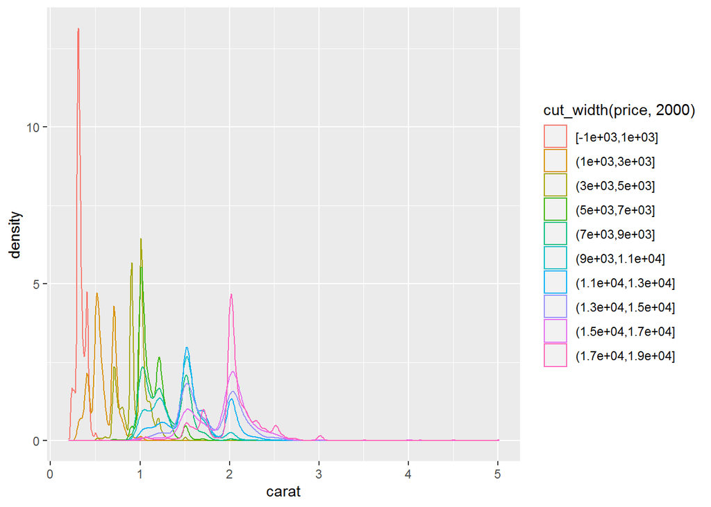

```r
diamonds%>%ggplot(aes(carat))+geom_density(aes(color=cut_width(price,2000)))
```

By using the density function, we could visulize the carat distribution in different price intervals represented by different colors of the curve. ## Exercise 3

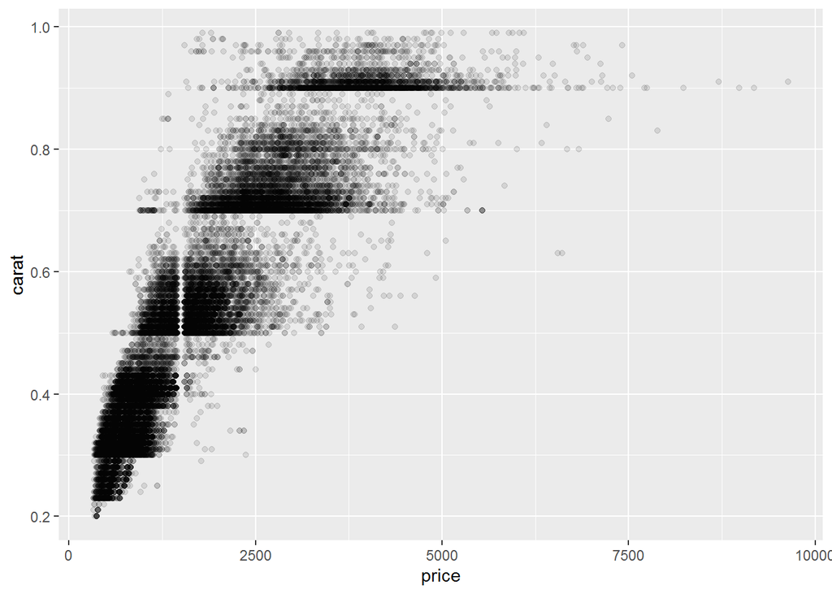

```r
diamonds%>%filter(carat<1)%>%ggplot(aes(price,carat))+geom_point(alpha=0.1)
```

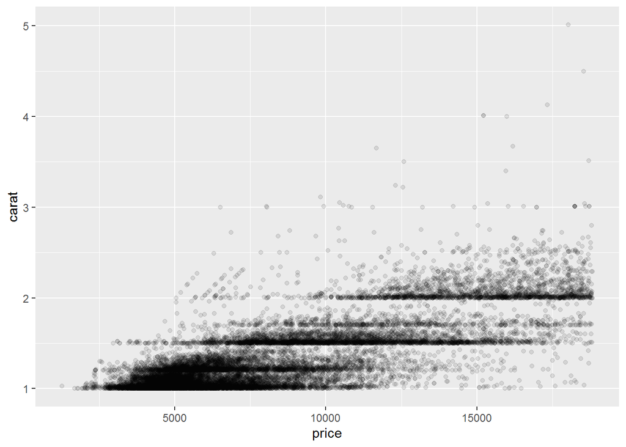

```r
diamonds%>%filter(carat>=1)%>%ggplot(aes(price,carat))+geom_point(alpha=0.1)
```

When the carat amount is lower than one(smaller diamond), it tends to have a stronger positive relationship with price and size and the slope is bigger. As carat amount is larger than 1, the slope tends to be smaller and the positive relationship tends to be weaker as the standard deviation is larger.

## Exercise 5

A two dimensional plot could form a pattern which is typicallly a regression line which you could easily observe which points are diverging from this trend. But for the one dimensional plot, it only focuses on binned counts, instead of showing the outlier